# NDVI in the Illilouette Creek Basin: examining changes after the introduction of managed wildfire

Rachel Pekelney & Joshua Hauser

Updated: 12 December 2021

## Introduction

The Illilouette Creek Basin (ICB) is a [150 km<sup>2</sup> area within Yosemite National Park](https://escholarship.org/content/qt7c71t4mr/qt7c71t4mr.pdf?t=onishe) that has experienced nearly half a century of managed wildfire, or naturally ignited fires that are permitted to burn in wilderness areas under the supervision of park and fire managers. The National Park Service adopted a policy of managed wildfire in the ICB in 1972. Preceded by a century of fire suppression, the managed wildfire period in the ICB has provided many insights into the role of fire as a disturbance and ecosystem process affecting vegetation structure, biodiversity, and water supply.

The ICB is a critical zone for research into the potential for managed wildfire to be used more broadly throughout Sierra Nevada forests to increase resiliency in the face of climate change. Only [8 hectares](https://escholarship.org/content/qt7c71t4mr/qt7c71t4mr.pdf?t=onishe) are known to have burned in the ICB between 1880-1973, whereas post-1972, over 50% of the total area in the basin has burned.

Native tribes across the country have been practicing cultural burning for [millennia](https://www.nps.gov/subjects/fire/indigenous-fire-practices-shape-our-land.htm). [Yosemite](https://atmos.earth/yosemite-indigenous-wildfire-history/) is no exception. Many tribes have lived in and visited Yosemite, including the Paiute and Mono tribes, the Sierra Miwoks, and the Ahwahnechee people. Tribes in the area practiced burning to cultivate resources, such as those for basketry and nutrition, to entertain, and to practice spiritual rituals. Their stewardship of the land created a patchy mosaic across the landscape that allowed for more species diversity and a more accessible landscape. As tribal chairman of the North Fork Mono, [Ron Goode](https://www.npr.org/2020/08/24/899422710/to-manage-wildfire-california-looks-to-what-tribes-have-known-all-along), said, “[Fire has] been in use for thousands and thousands of years. And so what we’re doing out here is restoring life.”

When settlers made it out West, however, they brutally punished cultural burning. “They didn’t understand fire in the sense of the tool that it could be to create and what it did to help generate and rejuvenate the land,” said Ron Goode, “so they brought in suppression.” Out of ignorance and racism, colonists destroyed a landscape that had been carefully looked after for generations.

Fire suppression led to [increased forest density, decreased biodiversity, and increased fuel loads](https://link.springer.com/content/pdf/10.1007/s10021-008-9211-7.pdf). Fuel — primarily small trees and decaying branches — has piled up over the decades of suppression, leading to calamitous conditions that result in massive, destructive fires. Having understood the importance of wildfire as a tool for ecosystem management, Yosemite National Park [reintroduced wildfire](https://iopscience.iop.org/article/10.1088/2515-7620/ac17e2) in 1972 in the ICB. Since then, fires that are naturally ignited in the ICB are allowed to burn, unless they pose a threat to human life.

Based on the [scientific literature](https://iopscience.iop.org/article/10.1088/2515-7620/ac17e2/pdf), forest ecologists have concluded that the reintroduction of wildfire reduces forest density and increases biodiversity through type conversion to shrubs and meadows while still preserving patches of mixed conifer forest. Shrubs and meadows [retain more ground water than dense forests](https://iopscience.iop.org/article/10.1088/2515-7620/ac17e2/pdf), making remaining forested areas more resilient to drought. We wanted to examine this change by looking at NDVI values before and after the introduction of managed wildfire. [NDVI (Normalized Difference Vegetation Index)](https://www.usgs.gov/special-topics/remote-sensing-phenology/science/ndvi-foundation-remote-sensing-phenology) is a measure of relative greenness or vegetation health, ranging from values of -1 (no living vegetation) to 1 (healthy vegetation). Our hypothesis was that, despite the benefits of increased biodiversity and watershed flow, NDVI in the ICB would have decreased overtime after the introduction of managed wildfire due to this type conversion.

## Fire perimeters in Yosemite and the Illilouette Creek Basin

First, we examined [historical fire data](https://frap.fire.ca.gov/frap-projects/fire-perimeters/) for [Yosemite National Park](https://irma.nps.gov/DataStore/Reference/Profile/2170436) as a whole to contextualize the change in fire patterns after 1972. We mapped fire perimeters onto a true color Landsat basemap.

```r
dir.create("data/fireperimeters")
download.file("https://frap.fire.ca.gov/media/50dgwqrb/fire20_1.zip", "data/fireperimeters/fire20_1.zip")
unzip("data/fireperimeters/fire20_1.zip",
      exdir = "data/fireperimeters/fireperimeters")
```

#### Fire Perimeters Mapped onto true color Landsat basemap

```r
# projected so everything is in WGS 84 / UTM Zone 11N
icb_shp_nad83 <- st_read("ill_wtrshd_nad83.shp")
icb_shp <- st_transform(icb_shp_nad83, crs(landsat_raster_b4))

# reading in RGB Landsat raster
landsat_refl_21 = rast("LC08_L1TP_042034_20210915_20210925_02_T1_refl.tif")
rgb = brick(landsat_refl_21)

cropped = crop(rgb, yos_bound)

fire_shp = st_read("California_Wildland_Fire_Perimeters_(All)/California_Wildland_Fire_Perimeters_(All).shp")
fire_shp_reproj = st_transform(fire_shp, crs(landsat_raster_b4))

keep <- st_is_valid(fire_shp_reproj)
```

The boundary of Yosemite National Park is shown in blue and the boundary of the ICB is shown in white. Historical fire perimeters are displayed with red borders and yellow fill.

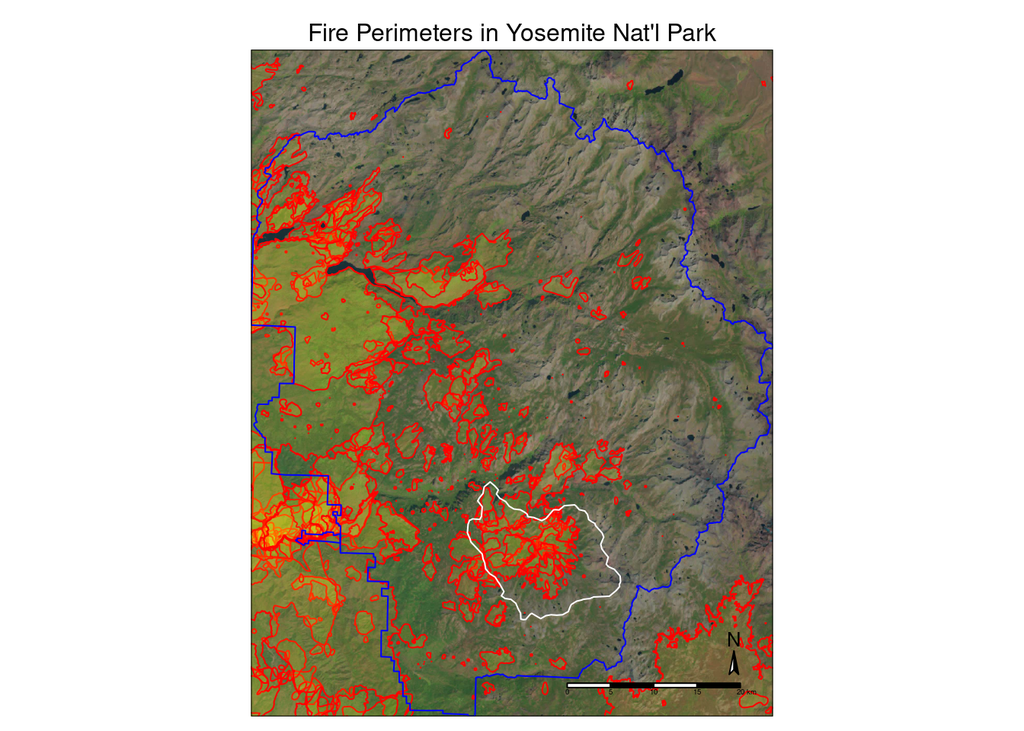

```r
tm_shape(cropped, bbox = st_bbox(yos_bound)) + tm_rgb() +
  fire_shp_reproj %>% filter(keep) %>%
  tm_shape(name="Fire Perimeters", bbox = st_bbox(yos_bound)) +
  tm_polygons(col = "yellow", border.col = "red", alpha = 0.1, lwd = 1) +
  tm_shape(yos_bound, name="Yosemite Nat'l Park") +
  tm_polygons(border.col = "blue",  alpha = 0) +
  tm_shape(icb_shp, name="ICB") + tm_polygons(border.col = "white",  alpha = 0) +
  tm_compass(size=1) + tm_scale_bar(size=0.3) +
  tm_layout(legend.outside=TRUE,
            main.title="Fire Perimeters in Yosemite Nat'l Park",
            main.title.size=1,
            main.title.position="center")
```

Darker yellow and red areas indicate locations where there have been repeated fires. We see a pattern of repeated fire in the ICB and a few other locations on the western side of the park. There have been fewer fires on the eastern side of the park, likely because much of this region is at higher elevations with sparser forest.

Our next step was to chart fire data in Yosemite over time. While the earliest year on record in this data set is 1933, it is important to note that the period of fire suppression extended further back into the mid 19th century.

```r
fireperimetersCA = as_tibble(fireperimeters)

# fire perimeters in Yosemite, post-1972 only
yos_fires_post72 = fireperimetersCA %>%
  filter(UNIT_ID == "YNP") %>%
  filter(YEAR_ > 1971) %>%
  arrange(YEAR_)

# fire perimeters in Yosemite, all historical data
yos_fires = fireperimetersCA %>%
  filter(UNIT_ID == "YNP") %>%
  arrange(YEAR_)
```

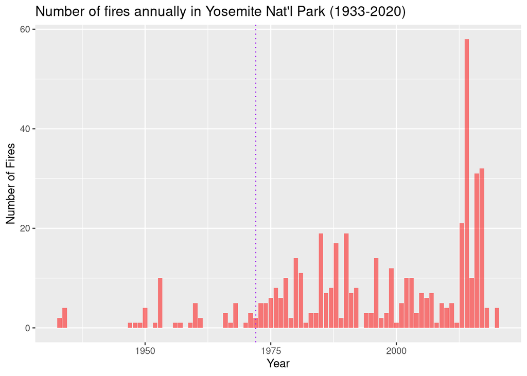

```r
# plotting number of fires per year since earliest data recorded
yos_fires %>%
  group_by(YEAR_) %>%
  summarise(n=n()) %>%
  mutate(YEAR_, Year = as.numeric(YEAR_)) %>%
  ggplot(aes(x=Year, y=n)) + geom_col(fill="red", alpha=0.5) +
  labs(y = "Number of Fires", title = "Number of fires annually in Yosemite Nat'l Park (1933-2020)") +
  geom_vline(aes(xintercept=1972), color="purple", linetype="dotted")
```

```r
# purple dotted line falls at year 1972, the beginning of the managed wildfire period
```

Our first chart shows the number of fires that occurred each year within the bounds of Yosemite National Park. The number of fires each year increased dramatically after 1972 (purple dotted line), when the NPS changed its policy to allow for managed wildfire. The period of fire suppression prior to 1972 experienced few fires. In more recent years, we see a spike in the number of fires; this is likely due to [climate change](https://www.washingtonpost.com/politics/2020/12/22/biden-wildfires/).

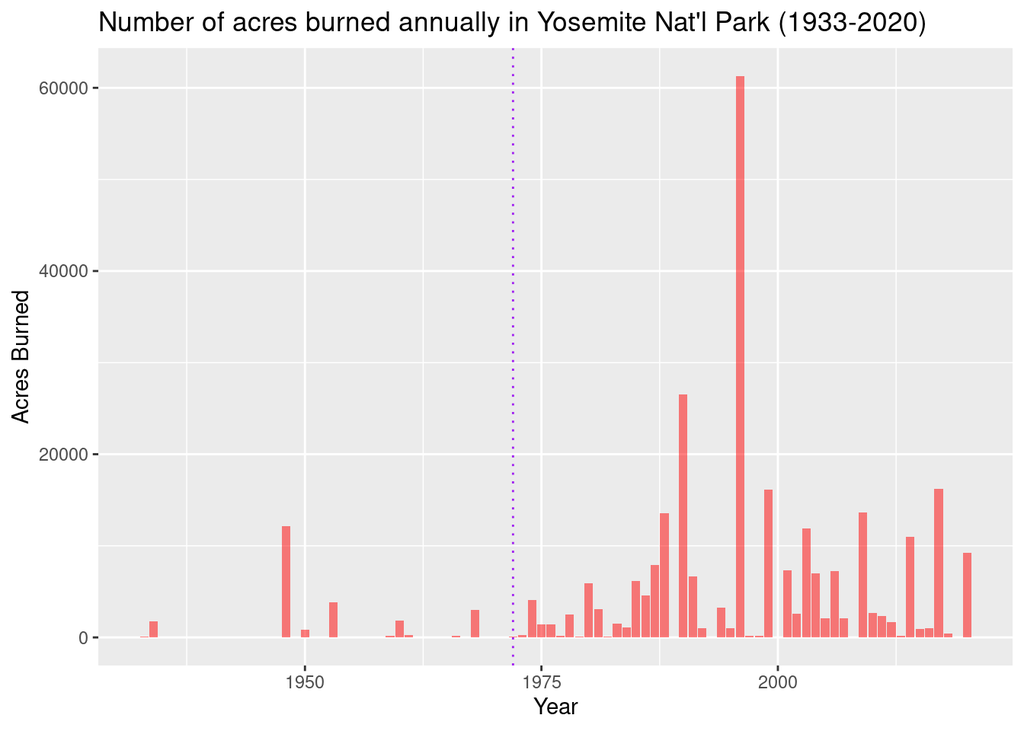

```r
yos_fires %>%
  mutate(YEAR_, Year = as.numeric(YEAR_)) %>%
  dplyr::select(Year, GIS_ACRES) %>%
  group_by(Year) %>%
  summarise(Acres_Burned = sum(GIS_ACRES)) %>%
  ggplot(aes(x=Year, y=Acres_Burned)) + geom_col(fill="red", alpha=0.5) +
  labs(y = "Acres Burned", title = "Number of acres burned annually in Yosemite Nat'l Park (1933-2020)") +
  geom_vline(aes(xintercept=1972), color="purple", linetype="dotted")
```

Another way to represent the change in fire patterns after the introduction of managed wildfire is through area burned. Similar to the previous chart, we see an increase in acres burned in Yosemite National Park after 1972 (represented by the purple line).

Total burn area can be a more useful variable than number of fires for understanding ecosystem impacts because it tells us about how much of the landscape was impacted by fire. We can see that while both the number of annual fires and acres burned increase after 1972, they do not share an identical pattern. This means that some years may have experienced more frequent but smaller fires while other years may have experience fewer but large fires. Another critical variable for understanding the ecosystem impacts of fire is burn severity, but we chose not to examine that here.

## Visualizing NDVI

Moving into the next part of our analysis, we sought to calculate NDVI in the ICB. Because of the challenges of importing and analyzing large amounts of raster data, we opted to compare Landsat imagery from 1972 and 2021 rather than at regular intervals over this time period. We selected images from the same time of year for both 1972 and 2021 to minimize any differences due to seasonal fluctuations.

NDVI is calculated using the red and near infrared (NIR) bands. The first Landsat satellite, Landsat 1, has different band designations than Landsat 8, which is currently in orbit. We made sure to select the band numbers corresponding to red and NIR for each Landsat satellite respectively. The spatial resolution also differs between Landsat 1 (60m) and Landsat 8 (30m). To make comparisons between the two, we resampled our 2021 Landsat image to 60m spatial resolution to match the imagery from 1972.

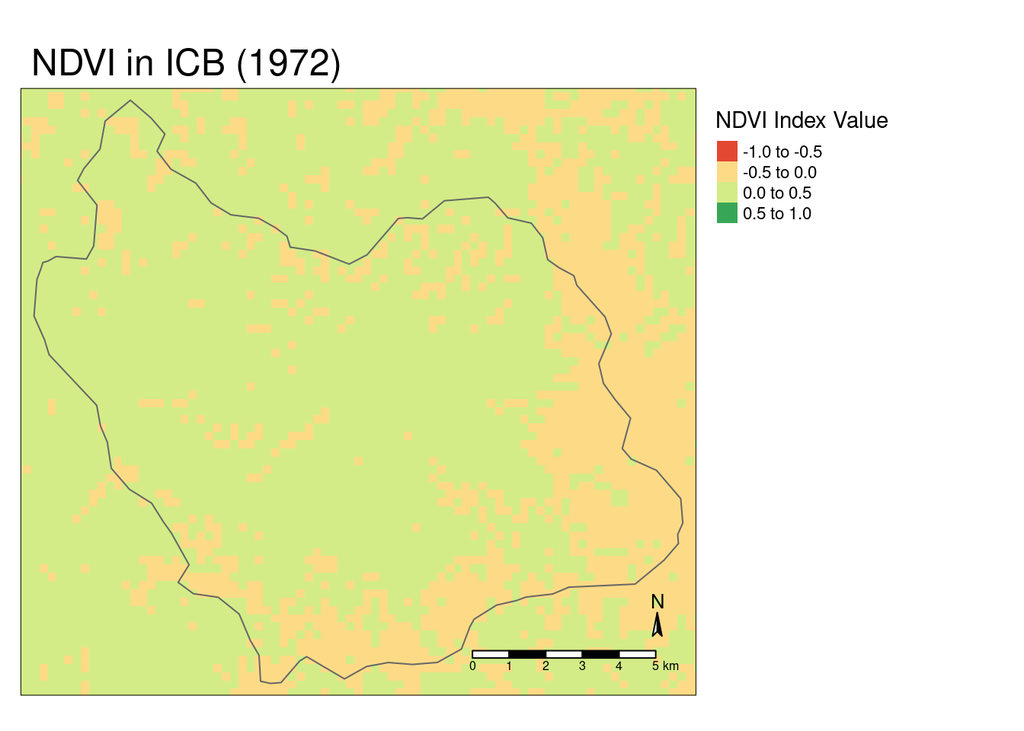

```r
# Landsat rasters for 9/16/1972
landsat72_raster_b5 <- rast("LM01_L1TP_045034_19720916_20200909_02_T2_B5.TIF")
landsat72_raster_b7 <- rast("LM01_L1TP_045034_19720916_20200909_02_T2_B7.TIF")

# for Landsat 1 [B5 = red and B7 = NIR]
# NDVI = (NIR - Red) / (NIR + Red)
landsat_ndvi72 <-
  (landsat72_raster_b7 - landsat72_raster_b5) / (landsat72_raster_b7 + landsat72_raster_b5)

# plot the data
tm_shape(landsat_ndvi72, bbox = st_bbox(icb_shp), title="NDVI") +
  tm_raster(midpoint = 0, title="NDVI Index Value") +
  tm_shape(icb_shp) + tm_polygons(alpha=0) +
  tm_compass(size=1) + tm_scale_bar() +
  tm_layout(main.title="NDVI in ICB (1972)", legend.outside = TRUE)
```

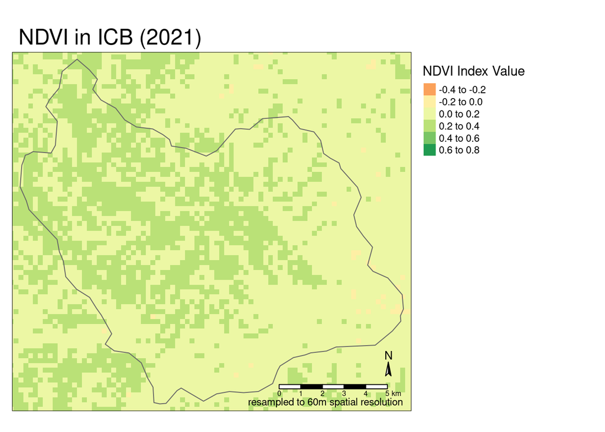

```r
# Landsat rasters for 9/15/21
landsat_raster_b4 <- rast("LC08_L1TP_042034_20210915_20210925_02_T1_B4.TIF")
landsat_raster_b5 <- rast("LC08_L1TP_042034_20210915_20210925_02_T1_B5.TIF")

# for Landsat 8 [B4 = Red and B5 = NIR]
# NDVI = (NIR - Red) / (NIR + Red)
landsat_ndvi <-
  (landsat_raster_b5 - landsat_raster_b4) / (landsat_raster_b5 + landsat_raster_b4)

# adjusting for different resolution in Landsat data from 1972 and 2021
resampled_ndvi21 <- resample(landsat_ndvi, landsat_ndvi72, method = "bilinear")

tm_shape(resampled_ndvi21, bbox = st_bbox(icb_shp)) +
  tm_raster(midpoint = 0, title="NDVI Index Value") +
  tm_shape(icb_shp) + tm_polygons(alpha=0) +
  tm_layout(main.title="NDVI in ICB (2021)", legend.outside = TRUE) +
  tm_compass(size=1) + tm_scale_bar() +
  tm_credits("resampled to 60m spatial resolution", position=c("RIGHT", "BOTTOM"))
```

Upon visual inspection, the NDVI in 1972 appears lower than in 2021. To better understand this difference and to assess if there was a change in NDVI, we plotted the distribution of NDVI values across the ICB for both years and overlaid them on a single chart:

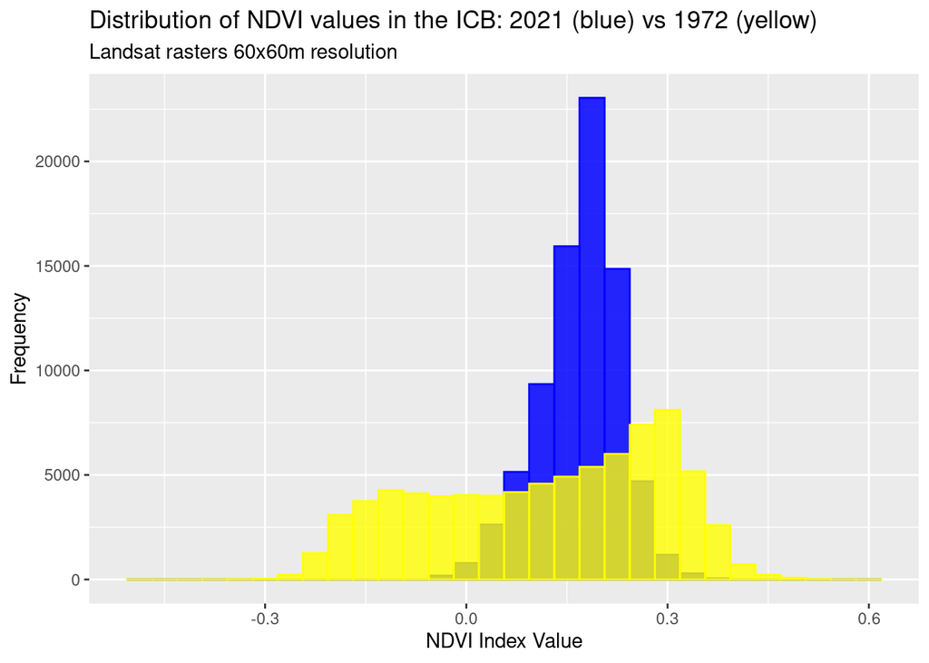

```r
# cropping NDVI rasters to ICB boundary
cropped21_rs = crop(resampled_ndvi21, icb_shp)
cropped21 = crop(landsat_ndvi, icb_shp)
cropped72 = crop(landsat_ndvi72, icb_shp)

# overlay histograms with ggplot
df_21 = as.data.frame(cropped21_rs)
df_72 = as.data.frame(cropped72)

ggplot() +
  geom_histogram(data=df_21,
                 aes(
                   x=LC08_L1TP_042034_20210915_20210925_02_T1_B5,
                   fill=LC08_L1TP_042034_20210915_20210925_02_T1_B5),
                 fill="blue",
                 color="blue",
                 alpha = .85) +
  geom_histogram(data=df_72,
                 aes(
                   x=LM01_L1TP_045034_19720916_20200909_02_T2_B7,
                   fill=LM01_L1TP_045034_19720916_20200909_02_T2_B7),
                 fill="yellow",
                 color="yellow",
                 alpha = .8) +
  ggtitle("Distribution of NDVI values in the ICB: 2021 (blue) vs 1972 (yellow)") +
  labs(x = "NDVI Index Value", y = "Frequency", subtitle = "Landsat rasters 60x60m resolution")
```

```r
# comparing mean NDVI in ICB in 1972 vs 2021

# mean NDVI in 2021
mean(df_21$LC08_L1TP_042034_20210915_20210925_02_T1_B5)
```

```
## [1] 0.1699134
```

```r
# mean NDVI in 1972
mean(df_72$LM01_L1TP_045034_19720916_20200909_02_T2_B7)
```

```
## [1] 0.1174481
```

```r
# comparing median NDVI in ICB in 1972 vs 2021

# median NDVI in 2021
median(df_21$LC08_L1TP_042034_20210915_20210925_02_T1_B5)
```

```
## [1] 0.1772041
```

```r
# median NDVI in 1972
median(df_72$LM01_L1TP_045034_19720916_20200909_02_T2_B7)
```

```
## [1] 0.1428571
```

## Discussion

We found that the average and median NDVI values in the ICB were higher in 2021 than in 1972 before the introduction of managed wildfire. There appears to be more variation in NDVI values in 1972 (the distribution is wider) relative to 2021 (the distribution is narrower).

Researchers have studied vegetation change in the ICB since the beginning of the managed wildfire period, observing that shrub and meadow areas have increased where there was previously dense mixed conifer forest. Our initial intuition was that denser forest areas would have a higher NDVI compared to forested areas combined with shrubs and meadows. While healthy forests, shrubs, and meadows (and other live vegetation) should all have a positive NDVI, it appears that there is not a major difference between NDVI values for these vegetation types. Statistical significance testing would be required to make any further conclusions about whether or not there is a difference.

One limitation to our analysis is that we chose only two years to make our comparison. We also did not account for fires or other disturbances that may have occurred quite recently before the two images were taken and which could have an impact on NDVI. Fires, drought, and windstorms that knock over trees and kill vegetation can impact NDVI calculations. To make our comparison more robust, it would have been beneficial to compare multiple historical Landsat images to multiple present-day Landsat images.

Another limitation to using NDVI as a single metric for studying vegetation change is that it does not tell us about the fine scale changes occurring on the ground. This is generally true of remotely sensed data; while it can be an incredibly useful tool for examining landscape-level processes and changes, it does not explain why changes occur nor what the overall ecosystems impacts may be. Thus, it is necessary to couple analyses of remotely sensed data with on-the-ground field observations.

## Conclusion

As one of the longest standing areas with natural fire reintroduced following the fire suppression era, the Illilouette Creek Basin is a key location for examining the holistic ecosystem impacts of managed wildfire. Understanding how the vegetation, biodiversity, and water resources have changed in the ICB is important for the application of managed wildfire to other wilderness areas. Based on numerous long-term studies of the ICB, there is a strong case for the use of managed wildfire as a strategy to increase forest resiliency in the Sierra Nevada in the face of frequent drought and warmer temperatures. Other wilderness areas, such as the Sugarloaf Creek Basin in Kings Canyon National Park, have also introduced managed wildfire and are seeing the resulting benefits. If used on a broader scale, this strategy has great potential to protect and improve the health of forest ecosystems in California under rapidly changing climatic conditions in the future.

## Sources

### Fire Perimeters:

[CAL FIRE Fire Perimeters](https://data.ca.gov/dataset/fire-perimeters1) downloaded from the CA State Open Data Portal, updated Dec. 2021 (used for mapping)

[FRAP Fire Perimeters](https://frap.fire.ca.gov/frap-projects/fire-perimeters/) (used for charting area burned annually and fires per year in Yosemite)

### ICB Shapefile:

Sourced from [Dr. Brandon M. Collins](https://nature.berkeley.edu/stephenslab/lab-members/dr-brandon-collins/), Berkeley Forests

### Yosemite Nat’l Park Boundary:

Accessed via the [National Park Service Data Store](https://irma.nps.gov/DataStore/) [(Park boundary updated as of 2006)](https://irma.nps.gov/DataStore/Reference/Profile/2170436)

### Landsat Rasters:

Downloaded from the [USGS EarthExplorer](https://earthexplorer.usgs.gov)

[Landsat 1:](https://www.usgs.gov/faqs/what-are-band-designations-landsat-satellites?qt-news_science_products=0#qt-news_science_products) Band 5 = red, Band 7 = NIR, date: 9/16/1972

[Landsat 8:](https://www.usgs.gov/faqs/what-are-band-designations-landsat-satellites?qt-news_science_products=0#qt-news_science_products) Band 4 = red, Band 5 = NIR, date: 9/15/2021

### Papers for Reference

[Boisrame, G., Thompson, S., Collins, B., Stephens, S. (2016). Managed Wildfire Effects on Forest Resilience and Water in the Sierra Nevada. Ecosystems, 20(4).](https://escholarship.org/content/qt7c71t4mr/qt7c71t4mr.pdf?t=onishe)

[Collins, B.M. et al. (2009). Interactions Among Wildland Fires in a Long-Established Sierra Nevada Natural Fire Area. Ecosystems, 12: 114–128.](https://link.springer.com/content/pdf/10.1007/s10021-008-9211-7.pdf)

[Hedges, R., Boisrame, G. (2019). Illilouette Creek Basin Research and Publications. UC Berkeley Stephens Lab.](https://nature.berkeley.edu/stephenslab/wp-content/uploads/2019/10/Illouette_Creek_Basin_Summary_FINAL.pdf)

[Stephens, S. et al. (2021). Fire, water, and biodiversity in the Sierra Nevada: a possible triple win. Environmental Research Communications, 3.](https://iopscience.iop.org/article/10.1088/2515-7620/ac17e2/pdf)